# LC-MS data processing with massFlowR

26 April 2020

**Package**: massFlowR  
**Authors**: Elzbieta Lauzikaite  
**Date**: Sun Apr 26 21:07:57 2020

# 1 Introduction

This documents provides an overview of the LC-MS data pre-processing with `massFlowR` using dataset faahKO.

# 2 Data import

LC-MS data in mzML/NetCDF format import is supported. Data import is implemented via mzR package.

In this document, functionality of the package will be demonstrated using data from faahKO package. Raw LC-MS data files (in NetCDF format) are provided for spinal cords samples taken from six knock-out (KO) and six wild-type (WT) mice. Each datafile contains centroided data acquired in positive ionization mode, with data recorded at 200-600 m/z and 2500-4500 seconds.

Load the package and locate the raw CDF files within the `faahKO` package:

```r
library(massFlowR)
## Get the full path to the CDF files
faahKO_files <- dir(system.file("cdf/WT", package = "faahKO"), full.names = TRUE)
```

| /Users/el1514/Library/R/3.6/library/faahKO/cdf/WT/wt15.CDF |
| --- |
| /Users/el1514/Library/R/3.6/library/faahKO/cdf/WT/wt16.CDF |
| /Users/el1514/Library/R/3.6/library/faahKO/cdf/WT/wt18.CDF |
| /Users/el1514/Library/R/3.6/library/faahKO/cdf/WT/wt19.CDF |
| /Users/el1514/Library/R/3.6/library/faahKO/cdf/WT/wt21.CDF |
| /Users/el1514/Library/R/3.6/library/faahKO/cdf/WT/wt22.CDF |

# 3 Individual samples processing

The first stage in the pipeline is chromatographic peak detection and grouping via function `groupPEAKS`.

## 3.1 Chromatographic peak detection

Peaks are detected using the *centWave* algorithm from xcms package (see (Tautenhahn, Bottcher, and Neumann 2008)). Appropriate parameters for the LC-MS experiment must be selected. For advise on this, please see the official `xcms` [manual](https://bioconductor.org/packages/release/bioc/vignettes/xcms/doc/xcms.html#3_initial_data_inspection). Selected parameters must be built into a *CentWaveParam* class object:

```r
## xcms parameters for peak-picking
cwt_param <- xcms::CentWaveParam(ppm = 25,
                                 snthresh = 10,
                                 noise = 1000,
                                 prefilter =  c(3, 100),
                                 peakwidth = c(30, 80),
                                 mzdiff = 0)
```

## 3.2 Chromatographic peak grouping

Detected peaks are put into groups, which comprise peaks originating from the same chemical compound: adducts and isotopes. For each peak in a sample, function `groupPEAKS`:

- Finds co-eluting chromatographic peaks;
- Performs extracted ion chromatogram (EIC) correlation between all co-eluting peaks;
- Builds a network of peaks with high EIC correlation;
- Detects communities of peak within the correlation network (implemented by `igraph` package algorithm, see (Raghavan, Albert, and Kumara 2007)).

Peaks that group into a community form a **pseudo chemical spectra**. Only communities with more than one peak are retained for further processing.

## 3.3 Implementation

Function `groupPEAKS` processes every LC-MS datafile independently and thus can be implemented in parallel, or during sample acquisition on the machine linked to the LC-MS. A list of paths to LC-MS datafiles (in mzML/NetCDF format) is feeded to `groupPEAKS`, together with the *CentWaveParam* class object, path to output directory and parameters for parallelisation.

`groupPEAKS` writes a csv with detected and grouped peaks in the selected directory for each LC-MS sample separately. The filenames of the generated csv files will be needed for the next stage in the pipeline. The filename starts with the original raw LC-MS filename and ends with “peakgrs.csv”.

`massFlowR` pipeline requires a metadata table with the following columns for each sample:

- `filename` specifies the basename of the raw LC-MS file.
- `run_order` specifies the acquisition order for the corresponding LC-MS sample.
- `raw_filepath` specifies the absolute path to the raw LC-MS file (netCDF/mzML).

```r
## define where processed datafiles should be written
# out_directory <- "absolute_path_to_output_directory"

## create metadata table with required columns 'filename', 'run_order' and 'raw_filepath'
metadata <-
  data.frame(
  filename = gsub(".CDF", "", basename(faahKO_files)),
  run_order = seq(length(faahKO_files)),
  raw_filepath = faahKO_files,
  stringsAsFactors = FALSE
  )
write.csv(metadata, file = file.path(out_directory, "metadata.csv"), row.names = FALSE)
```

| filename | run_order | raw_filepath |
| --- | --- | --- |
| wt15 | 1 | /Users/el1514/Library/R/3.6/library/faahKO/cdf/WT/wt15.CDF |
| wt16 | 2 | /Users/el1514/Library/R/3.6/library/faahKO/cdf/WT/wt16.CDF |
| wt18 | 3 | /Users/el1514/Library/R/3.6/library/faahKO/cdf/WT/wt18.CDF |
| wt19 | 4 | /Users/el1514/Library/R/3.6/library/faahKO/cdf/WT/wt19.CDF |
| wt21 | 5 | /Users/el1514/Library/R/3.6/library/faahKO/cdf/WT/wt21.CDF |
| wt22 | 6 | /Users/el1514/Library/R/3.6/library/faahKO/cdf/WT/wt22.CDF |

```r
## run peak detection and grouping for the listed faahKO files with two workers
groupPEAKS(file = file.path(out_directory, "metadata.csv"), out_dir = out_directory, cwt = cwt_param, ncores = 2)
```

```
#> 2 out of 6 files were processed.
#> 4 out of 6 files were processed.
#> 6 out of 6 files were processed.
#> Peak-groups for all files were succesfully generated.
```

# 4 Peak alignment

To align structurally-related peaks as a group across samples in LC-MS experiment, an alignment algorithm, which preserves the structural spectral information, is implemented.

Peaks are aligned by taking samples in the order of raw sample acquisition and matching them against a template. Template is list of all previously aligned peaks, which is updated with each sample by:

- adding new peaks
- averaging the *m/z* and *rt* values of matching peaks between the sample and the template.

Therefore, template stores the **moving averages** of *m/z* and *rt* values.

For each peak in a sample, alignment algorithm:

1. Finds all template peaks within a *m/z* and *rt* window.
2. Identifies the true match by comparing the spectral similarity between the peak-group of the peak-of-interest and all matching template’s peak-groups.
3. Merges the selected template’s peak-group with the peak-group of the peak-of-interest. It updates template’s *m/z* and *rt* values for the matching peaks across the template and the sample.

Spectral similarity is measured by obtaining the cosine of the angle between two 2D vectors, representing each PCSs *m/z* and *intensity* values.

## 4.1 Implementation

To enable peak alignment, previous metadata table has to contain additional column:

- `proc_filepath` specifies the absolute path to the csv files generated by the `groupPEAKS` function.

```r
##  update previous metadata table and add paths to generated csv files
processed_files <- list.files(out_directory, "peakgrs.csv", full.names = TRUE)
metadata$proc_filepath <- processed_files
write.csv(metadata, file.path(out_directory, "metadata_grouped.csv"), row.names = FALSE)
```

| filename | run_order | raw_filepath | proc_filepath |
| --- | --- | --- | --- |
| wt15 | 1 | /Users/el1514/Library/R/3.6/library/faahKO/cdf/WT/wt15.CDF | /Users/el1514/Documents/Scripts/massFlowR/vignettes/wt15_peakgrs.csv |
| wt16 | 2 | /Users/el1514/Library/R/3.6/library/faahKO/cdf/WT/wt16.CDF | /Users/el1514/Documents/Scripts/massFlowR/vignettes/wt16_peakgrs.csv |
| wt18 | 3 | /Users/el1514/Library/R/3.6/library/faahKO/cdf/WT/wt18.CDF | /Users/el1514/Documents/Scripts/massFlowR/vignettes/wt18_peakgrs.csv |
| wt19 | 4 | /Users/el1514/Library/R/3.6/library/faahKO/cdf/WT/wt19.CDF | /Users/el1514/Documents/Scripts/massFlowR/vignettes/wt19_peakgrs.csv |
| wt21 | 5 | /Users/el1514/Library/R/3.6/library/faahKO/cdf/WT/wt21.CDF | /Users/el1514/Documents/Scripts/massFlowR/vignettes/wt21_peakgrs.csv |
| wt22 | 6 | /Users/el1514/Library/R/3.6/library/faahKO/cdf/WT/wt22.CDF | /Users/el1514/Documents/Scripts/massFlowR/vignettes/wt22_peakgrs.csv |

To initiate peak alignment, use function `buildTMP`, which constructs a `massFlowTemplate`class object. `massFlowTemplate` object stores sample alignment and annotation data and is updated with every sample. Define the desired error window for *m/z* and *rt* (seconds) values, which will be used for the whole experiment. `mz_err = 0.01` and `rt_err = 2` are recommended for high-resolution UPLC-MS data. `mz_err = 0.01` and `rt_err = 10` are suitable for the `faahKO`package data.

Desired spectral similarity threshold can be selected with *cutoff* parameter (0-1, with 1 being perfectly identical). `cutoff = 0.5` is recommended for high-resolution UPLC-MS data

```r
## initiate template
template <- buildTMP(file = file.path(out_directory, "metadata_grouped.csv"), out_dir = out_directory, mz_err = 0.01, rt_err = 10, cutoff = 0.5)
```

```
#> Building template using sample: wt15  ...
```

To review the samples that are in the experiment, use slot `@samples`.

```r
## review samples in the experiment using slot "samples"
template@samples
```

| filename | run_order | raw_filepath | proc_filepath | aligned | aligned_filepath |
| --- | --- | --- | --- | --- | --- |
| wt15 | 1 | /Users/el1514/Library/R/3.6/library/faahKO/cdf/WT/wt15.CDF | /Users/el1514/Documents/Scripts/massFlowR/vignettes/wt15_peakgrs.csv | TRUE | /Users/el1514/Documents/Scripts/massFlowR/vignettes/wt15_aligned.csv |
| wt16 | 2 | /Users/el1514/Library/R/3.6/library/faahKO/cdf/WT/wt16.CDF | /Users/el1514/Documents/Scripts/massFlowR/vignettes/wt16_peakgrs.csv | FALSE | NA |
| wt18 | 3 | /Users/el1514/Library/R/3.6/library/faahKO/cdf/WT/wt18.CDF | /Users/el1514/Documents/Scripts/massFlowR/vignettes/wt18_peakgrs.csv | FALSE | NA |
| wt19 | 4 | /Users/el1514/Library/R/3.6/library/faahKO/cdf/WT/wt19.CDF | /Users/el1514/Documents/Scripts/massFlowR/vignettes/wt19_peakgrs.csv | FALSE | NA |
| wt21 | 5 | /Users/el1514/Library/R/3.6/library/faahKO/cdf/WT/wt21.CDF | /Users/el1514/Documents/Scripts/massFlowR/vignettes/wt21_peakgrs.csv | FALSE | NA |
| wt22 | 6 | /Users/el1514/Library/R/3.6/library/faahKO/cdf/WT/wt22.CDF | /Users/el1514/Documents/Scripts/massFlowR/vignettes/wt22_peakgrs.csv | FALSE | NA |

`massFlowTemplate` object stores the most up-to-date template in the `@tmp` slot. Function `buildTMP` creates a template using the first sample in the experiment.

```r
## review gnerated template using slot "tmp"
head(template@tmp, 20)
```

| peakid | mz | rt | into | peakgr |
| --- | --- | --- | --- | --- |
| 1 | 508.2 | 3515.468 | 53910493 | 1 |
| 2 | 496.2 | 3384.012 | 38200390 | 2 |
| 3 | 343.0 | 2678.218 | 26239739 | 3 |
| 4 | 524.2 | 3662.573 | 26223613 | 4 |
| 5 | 526.1 | 3168.048 | 25760336 | 5 |
| 6 | 522.2 | 3344.888 | 23482538 | 6 |
| 7 | 502.1 | 3157.093 | 20113369 | 7 |
| 8 | 522.2 | 3409.051 | 19327938 | 8 |
| 9 | 365.0 | 2679.783 | 15389162 | 3 |
| 10 | 509.2 | 3517.033 | 15123847 | 1 |
| 11 | 496.2 | 3316.719 | 13639593 | 9 |
| 12 | 497.2 | 3384.012 | 10219380 | 2 |
| 13 | 360.0 | 2684.478 | 10062820 | 10 |
| 14 | 464.2 | 3454.435 | 9807117 | 11 |
| 15 | 577.4 | 4122.670 | 9073006 | 12 |
| 16 | 482.2 | 3585.891 | 9047697 | 13 |
| 17 | 525.2 | 3662.573 | 7829455 | 4 |
| 18 | 527.1 | 3168.048 | 7615135 | 5 |
| 19 | 531.2 | 3344.888 | 7268278 | 6 |
| 20 | 523.2 | 3344.888 | 6909134 | 6 |

To align peaks across all samples in the study, apply method `alignPEAKS`. `alignPEAKS` updates the `massFlowTemplate` object:

1. Selects next sample to be aligned and checks whether it was already peak-picked and grouped (waits until the corresponding csv file is written, see).
2. Matches every peak in the sample against the template.
3. Selects best matches using spectral similarity comparison.
4. Updates template with sample’s peaks: adds new and averages matching peaks.

Parameter `ncores` allows a quicker implementation using the parallel backend that is available on the user’s machine (i.e. multicore on Unix/Mac and snow on Windows). Select the desired number of parallel workers.

```r
## align peaks across all remaining samples
template <- alignPEAKS(template, out_dir = out_directory, ncores = 2)
```

```
#> 5 out of 6 samples left to align.
#> Aligning to sample: wt16 ...
#> 4 out of 6 samples left to align.
#> Aligning to sample: wt18 ...
#> 3 out of 6 samples left to align.
#> Aligning to sample: wt19 ...
#> 2 out of 6 samples left to align.
#> Aligning to sample: wt21 ...
#> 1 out of 6 samples left to align.
#> Aligning to sample: wt22 ...
#> Peaks were aligned across all samples.
```

Aligned sample’s peak tables are stored within the `@data` slot, which lists tables for each sample separately.

```r
## review alignment results for an individual sample, e.g. the second, using slot "data"
head(template@data[[2]])
```

| peakid | mz | mzmin | mzmax | rt | rtmin | rtmax | into | intb | maxo | sn | egauss | mu | sigma | h | f | dppm | scale | scpos | scmin | scmax | lmin | lmax | sample | peakgr | tmp_peakid | tmp_peakgr | cos |
| --- | --- | --- | --- | --- | --- | --- | --- | --- | --- | --- | --- | --- | --- | --- | --- | --- | --- | --- | --- | --- | --- | --- | --- | --- | --- | --- | --- |
| 1 | 508.2 | 508.2 | 508.2 | 3532.682 | 3498.253 | 3571.806 | 56426907 | 55783902 | 1336832 | 189 | NA | NA | NA | NA | 3887 | 0 | 10 | 660 | 650 | 670 | 95 | 142 | 1 | 1 | 1 | 1 | 0.9921128 |
| 2 | 496.2 | 496.2 | 496.2 | 3407.486 | 3374.622 | 3443.480 | 34418258 | 33952491 | 1064960 | 190 | NA | NA | NA | NA | 3009 | 0 | 10 | 580 | 570 | 590 | 127 | 171 | 1 | 2 | 269 | 82 | NA |
| 3 | 524.2 | 524.2 | 524.2 | 3693.872 | 3659.443 | 3734.561 | 32311995 | 31172950 | 821056 | 40 | NA | NA | NA | NA | 3674 | 0 | 10 | 763 | 753 | 773 | 75 | 123 | 1 | 3 | 324 | 97 | NA |
| 4 | 526.1 | 526.1 | 526.1 | 3180.567 | 3146.138 | 3216.561 | 27029850 | 25682671 | 769536 | 29 | NA | NA | NA | NA | 1862 | 0 | 10 | 435 | 425 | 445 | 79 | 124 | 1 | 4 | 5 | 5 | 0.9763828 |
| 5 | 530.2 | 530.2 | 530.2 | 3357.407 | 3326.108 | 3396.531 | 26175357 | 25052715 | 831104 | 50 | NA | NA | NA | NA | 2340 | 0 | 10 | 548 | 538 | 558 | 78 | 123 | 1 | 5 | 260 | 78 | NA |
| 6 | 522.2 | 522.2 | 522.2 | 3365.232 | 3324.543 | 3401.226 | 24818362 | 24519586 | 809088 | 153 | NA | NA | NA | NA | 3014 | 0 | 14 | 553 | 539 | 567 | 73 | 122 | 1 | 6 | 263 | 79 | NA |

## 4.2 Alignment re-initiation

If alignment was stopped before all samples in the experiment could be aligned (for example, because of a computer issue), alignmment can be re-initiated by loading the samples that had already been processed. Function `loadALIGNED` requires the absolute paths to the updated metadata file and the final template writen by `alignPEAKS`. Note that same parameters must be provided as for the `buildTMP` function.

```r
## get the absolute paths to the updated metadata file and the final template writen by "alignPEAKS"
m_file <- file.path(out_directory, "aligned.csv")
tmp_file <- file.path(out_directory, "template.csv")

## load already aligned samples into a massFlowTemplate object
template <- loadALIGNED(file = m_file, template = tmp_file, mz_err = 0.01, rt_err = 10, cutoff = 0.5)
```

```
#> A 'massFlowTemplate' object was succesfully built with aligned samples.
```

```r
## if some of the samples in the experiment have not been aligned yet, re-start alignment
template@samples$aligned
```

```
#> [1] TRUE TRUE TRUE TRUE TRUE TRUE
```

```r
if (any(template@samples$aligned == FALSE)) {
  template <- alignPEAKS(template, out_dir = out_directory, ncores = 2)
}
```

## 4.3 Realtime implementation

Sample alignment can be performed in real-time during data acquisition by setting the `buildTMP` function parameter to `realtime = TRUE`. The function will wait for the intermediate peak-groups csv files to be written instead of stopping when a file that does not exist is encountered. Make sure, however, that correct filepaths are provided in the metadata csv file’s column `proc_filepath`.

```r
template <- buildTMP(file = file.path(out_directory, "metadata_grouped.csv"), out_dir = out_directory, mz_err = 0.01, rt_err = 10, cutoff = 0.5, realtime = TRUE)
template <- alignPEAKS(template, out_dir = out_directory, ncores = 2)
```

# 5 Alignment validation

Once peaks are aligned across all samples, the obtained peak-groups are validated. Intensity values for each peak in a group are correlated across all samples. Correlation estimates are then used to build networks of peaks, that behave similarly across all samples. Peaks exhibiting a different pattern in their intensities are put into a new peak-group.

Each peak-group is a *pseudo chemical spectra* (PCS), which comprised peaks exhibiting consistent behaviour across samples.

To enable alignment validation, a metadata table and final template file that both were written by the `alignPEAKS` function in the selected directory, must be used. A `massFlowTemplate`class object, returned by the `alignPEAKS` function will be needed. If alignment validation will be performed in a new R session, re-initiate the `massFlowTemplate`class objec using `loadALIGNED` function as before.

```r
## get the absolute paths to the updated metadata file and the final template writen by "alignPEAKS"
m_file <- file.path(out_directory, "aligned.csv")
tmp_file <- file.path(out_directory, "template.csv")

## initiate validation by first loading aligned samples into a massFlowTemplate object
template <- loadALIGNED(file = m_file, template = tmp_file)
```

```
#> A 'massFlowTemplate' object was succesfully built with aligned samples.
```

Peak-group validation is enabled by applying the method `validPEAKS` on the `massFlowTemplate`class object. Validation can be implemented in parallel using `ncores` parameter.

`validPEAKS` will return a `massFlowTemplate`class object with validated *pseudo chemical spectra*, as well as write peak tables for the obtained PCS:

- intensity_data.csv (intensity values for every peak in PCS in every sample)
- peaks_data.csv
- sample_data.csv

```r
## Start validation using a massFlowTemplate object
template <- validPEAKS(template, out_dir = out_directory, ncores = 2, cor_thr = 0.5)
```

```
#> value for 'min_samples_prop' not provided. Setting the minimum number of samples to 3!
#> All peak-groups were succesfully validated.
```

# 6 Peak filling

Final step in the pipeline is to re-integrate intensity values for peaks that were not detected by the *centWave* using raw LC-MS files. In contrast to `xcms` package, *m/z* and *rt* values for intensity integration are estimated for each sample separetely. *m/z* and *rt* values are modelled using a cubic smoothing spline.

```r
## Fill peaks using validated massFlowTemplate object
template <- fillPEAKS(template, out_dir = out_directory, ncores = 2)
```

```
#> 6 samples left to fill.
#> Filling next 2 samples:
#> wt15
#> wt16
#>  ...
#> 4 samples left to fill.
#> Filling next 2 samples:
#> wt18
#> wt19
#>  ...
#> 2 samples left to fill.
#> Filling next 2 samples:
#> wt21
#> wt22
#>  ...
#> All peak-groups were succesfully filled
```

# 7 Final output

`fillPEAKS` writes file ‘filled_intensity_data.csv’, which contains features metadata (including pseudo chemical spectra number) and intensity values for each sample in the experiment.

```r
final_dt <- read.csv(file.path(out_directory, "filled_intensity_data.csv"), header = TRUE, stringsAsFactors = FALSE)
```

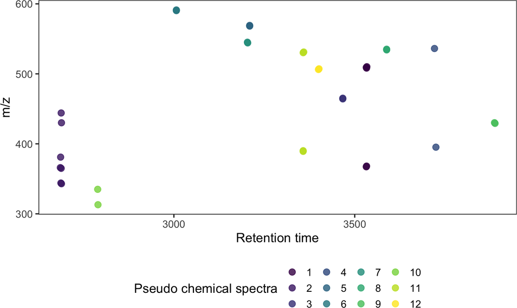

# 8 Peak annotation

If in-house chemical reference database is available, PCS are annotated. For more details how to build a database file, see [annotation using database](https://htmlpreview.github.io/?https://github.com/lauzikaite/massFlowR/blob/master/vignettes/annotation.html)).

# 9 See also

- [massFlowR overview](https://htmlpreview.github.io/?https://github.com/lauzikaite/massFlowR/blob/master/vignettes/massFlowR.html)
- [Automatic annotation](https://htmlpreview.github.io/?https://github.com/lauzikaite/massFlowR/blob/master/vignettes/annotation.html)

# References

Raghavan, Usha Nandini, Réka Albert, and Soundar Kumara. 2007. “Near linear time algorithm to detect community structures in large-scale networks.” *Physical Review E* 76 (3): 036106. https://doi.org/10.1103/PhysRevE.76.036106.